# ANOVA Models

Antigoni Kaliontzopoulou, Dean Adams & Michael Collyer

28 May, 2026

## **Content Description**

In `geomorph`, ANOVA models are performed using Procrustes ANOVA. Factorial models can also be performed. The primary function for this is `procD.lm`, which is a wrapper for the `lm.rrpp` function in the package `RRPP`. This latter function contains myriad options and is quite flexible for evaluating linear model designs.

Here we demonstrate some of that flexibility: the user is strongly encouraged to work through the various vignettes that accompany both `geomorph` and `RRPP` which provide additional hints on usage, and other valuable information.

Here are some examples for performing ANOVA-based models and pairwise comparisons in `geomorph` and `RRPP`. First, let’s load some data:

```r
library(geomorph)
```

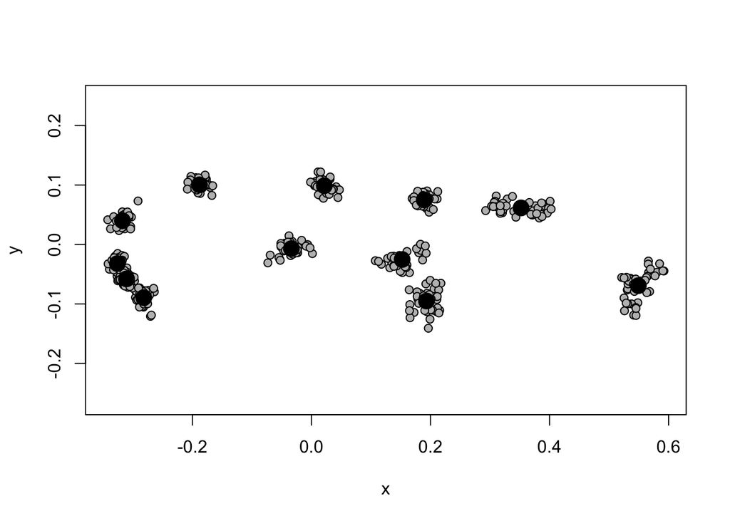

```r
data(plethodon)
Y.gpa <- gpagen(plethodon$land, print.progress = FALSE)
plot(Y.gpa)
```

### **Single-Factor ANOVA (though multivariate data)**

Here is an example of a single-factor ANOVA for shape data; comparing species:

```r
gdf <- geomorph.data.frame(Y.gpa,
                           site = plethodon$site,
                           species = plethodon$species,
                           gp = interaction(plethodon$species, plethodon$site)) # geomorph data frame

pleth.anova <- procD.lm(coords ~ species, data = gdf, print.progress = FALSE)
summary(pleth.anova)
```

```
##
## Analysis of Variance, using Residual Randomization
## Permutation procedure: Randomization of null model residuals
## Number of permutations: 1000
## Estimation method: Ordinary Least Squares
## Sums of Squares and Cross-products: Type I
## Effect sizes (Z) based on F distributions
##
##           Df       SS        MS     Rsq      F      Z Pr(>F)
## species    1 0.029258 0.0292578 0.14856 6.6304 3.1843  0.001 ***
## Residuals 38 0.167682 0.0044127 0.85144
## Total     39 0.196940
## ---
## Signif. codes:  0 '***' 0.001 '**' 0.01 '*' 0.05 '.' 0.1 ' ' 1
##
## Call: procD.lm(f1 = coords ~ species, data = gdf, print.progress = FALSE)
```

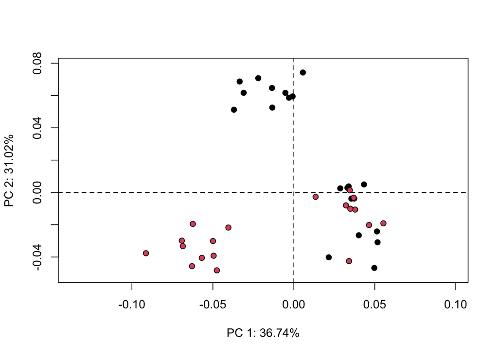

```r
PCA <- gm.prcomp(Y.gpa$coords)
plot(PCA, pch = 21, bg = gdf$species)
```

From this it seems that species differ, though our PCA plot reveals that there may be some additional structure in the data.

### **Single-Factor MANOVA (an update to include MANOVA statistics)**

The “ANOVA” in procD.lm is a Procrustes ANOVA based on distances between different versions of fitted shapes and residuals. The statistics are the same as univariate ANOVA statistics and if performed on univariate data, the statistics do not change from those returned from a univariate ANOVA. This is not true of MANOVA statistics (which would have to be converted to $F$-values for parametric tests.) We can update our model fit to provide MANOVA statistics. This takes some time for computations, but is quite easy to do.

```r
pleth.manova <- manova.update(pleth.anova, tol = 0, print.progress = FALSE)
summary(pleth.manova)
```

```
##
## Linear Model fit with lm.rrpp
##
## Number of observations: 40
## Number of dependent variables: 24
## Data space dimensions: 24
## Residual covariance matrix rank: 20
## Sums of Squares and Cross-products: Type I
## Number of permutations: 1000
##
##            Df Rand      Roy      Z        Pr(>Roy)
## species     1 Residuals 3.074317 2.402608 0.009
## Full.Model  1 Residuals 3.074317 2.402608 0.009
## Residuals  38
```

```r
summary(pleth.manova, test = "Pillai")
```

```
##
## Linear Model fit with lm.rrpp
##
## Number of observations: 40
## Number of dependent variables: 24
## Data space dimensions: 24
## Residual covariance matrix rank: 20
## Sums of Squares and Cross-products: Type I
## Number of permutations: 1000
##
##            Df Rand      Pillai    Z        Pr(>Pillai)
## species     1 Residuals 0.7545601 2.269217 0.009
## Full.Model  1 Residuals 0.7545601 2.269217 0.009
## Residuals  38
```

```r
summary(pleth.manova, test = "Wilks")
```

```
##
## Linear Model fit with lm.rrpp
##
## Number of observations: 40
## Number of dependent variables: 24
## Data space dimensions: 24
## Residual covariance matrix rank: 20
## Sums of Squares and Cross-products: Type I
## Number of permutations: 1000
##
##            Df Rand      Wilks     Z        Pr(<Wilks)
## species     1 Residuals 0.2454399 2.232553 0.009
## Full.Model  1 Residuals 0.2454399 2.232553 0.009
## Residuals  38
```

The `tol` argument could be set to 0 because the observations outnumber the shape variables. This could be adjusted if shape variables outnumber observations (to prevent problems with matrix inversion). The help file for `manova.update` can help explain more. This concern does not exists with ANOVA statistics.

### **Factorial ANOVA/MANOVA**

One can also perform factorial designs using the RRPP perspective:

```r
pleth.anova2 <- procD.lm(coords ~ species*site, data = gdf, print.progress = FALSE)
summary(pleth.anova2)
```

```
##
## Analysis of Variance, using Residual Randomization
## Permutation procedure: Randomization of null model residuals
## Number of permutations: 1000
## Estimation method: Ordinary Least Squares
## Sums of Squares and Cross-products: Type I
## Effect sizes (Z) based on F distributions
##
##              Df       SS       MS     Rsq      F      Z Pr(>F)
## species       1 0.029258 0.029258 0.14856 14.544 4.2241  0.001 ***
## site          1 0.064375 0.064375 0.32688 32.000 5.2101  0.001 ***
## species:site  1 0.030885 0.030885 0.15682 15.352 5.4075  0.001 ***
## Residuals    36 0.072422 0.002012 0.36774
## Total        39 0.196940
## ---
## Signif. codes:  0 '***' 0.001 '**' 0.01 '*' 0.05 '.' 0.1 ' ' 1
##
## Call: procD.lm(f1 = coords ~ species * site, data = gdf, print.progress = FALSE)
```

This analysis reveals that there are differences among species and sites. **However**, the interaction term is highly significant and with a strong effect (note the $\small{Z-score}$). Thus, further analyses via pairwise comparisons will be important.

```r
# Before performing pairwise comparisons, it might be useful to see what the null model is
reveal.model.designs(pleth.anova2)
```

```
##                      Reduced                           Full
## species                    1                        species
## site                 species                 species + site
## species:site  species + site  species + site + species:site
##
## species
## site
## species:site <- Null/Full inherent in pairwise
```

```r
pleth.pw <- pairwise(pleth.anova2, groups = gdf$gp)
summary(pleth.pw, confidence = 0.95, test.type = "dist")
```

```
##
## Pairwise comparisons
##
## Groups: Jord.Allo Teyah.Allo Jord.Symp Teyah.Symp
##
## RRPP: 1000 permutations
##
## LS means:
## Vectors hidden (use show.vectors = TRUE to view)
##
## Pairwise distances between means, plus statistics
##                                d  UCL (95%)          Z Pr > d
## Jord.Allo:Teyah.Allo  0.02432519 0.07774489 -3.1495859  1.000
## Jord.Allo:Jord.Symp   0.09566672 0.09226464  2.2305051  0.015
## Jord.Allo:Teyah.Symp  0.10136696 0.11812556 -0.1921641  0.568
## Teyah.Allo:Jord.Symp  0.09193082 0.10897149 -0.3111746  0.628
## Teyah.Allo:Teyah.Symp 0.09949800 0.09314049  2.6760941  0.003
## Jord.Symp:Teyah.Symp  0.10694324 0.07639056  3.9866153  0.001
```

The pairwise test above is most appropriate. It considers which means are different, after accounting for species and site effects. We could ignore that and use a different null model. It is always wise to consider the most appropriate null model. Following is a poor choice, run just to illustrate how one can control the analysis.

```r
pleth.null <- procD.lm(coords ~ 1, data = gdf, print.progress = FALSE)
pleth.pw2 <- pairwise(pleth.anova2, fit.null = pleth.null, groups = gdf$gp)
summary(pleth.pw2, confidence = 0.95, test.type = "dist")
```

```
##
## Pairwise comparisons
##
## Groups: Jord.Allo Teyah.Allo Jord.Symp Teyah.Symp
##
## RRPP: 1000 permutations
##
## LS means:
## Vectors hidden (use show.vectors = TRUE to view)
##
## Pairwise distances between means, plus statistics
##                                d  UCL (95%)          Z Pr > d
## Jord.Allo:Teyah.Allo  0.02432519 0.04819806 -0.5573506  0.712
## Jord.Allo:Jord.Symp   0.09566672 0.04877290  4.3877296  0.001
## Jord.Allo:Teyah.Symp  0.10136696 0.04754707  4.3991515  0.001
## Teyah.Allo:Jord.Symp  0.09193082 0.04808437  3.7337127  0.001
## Teyah.Allo:Teyah.Symp 0.09949800 0.04807936  3.7391111  0.001
## Jord.Symp:Teyah.Symp  0.10694324 0.04798575  4.4194571  0.001
```

This pairwise test assumes just an overall mean is an appropriate null model, and species and site effects should not be considered. *This is a really stupid null model!* But just as forcing this null model is foolish, not considering the null model and using whatever is the default, is equally foolish.

Additionally, we would like to visualize patterns associated with the ANOVA and pairwise comparisons. We accomplish this via PCA plots and TPS deformation grids:

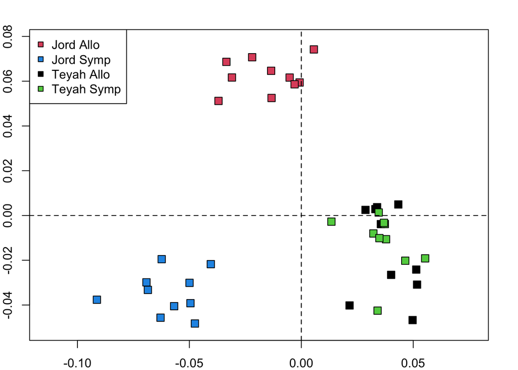

```r
pleth.raw <- gm.prcomp(Y.gpa$coords)
gps <- as.factor(paste(plethodon$species, plethodon$site))
par(mar=c(2, 2, 2, 2))
plot(pleth.raw, pch=22, cex = 1.5, bg = gps)
#  Add things as desired using standard R plotting
legend("topleft", pch=22, pt.bg = unique(gps), legend = levels(gps))
```

```r
M <- mshape(Y.gpa$coords)
pleth.anova <- procD.lm(coords ~ species*site, data=gdf, print.progress = FALSE)
X <- pleth.anova$X
X[1:10,] # includes intercept; remove for better functioning
```

```
##    (Intercept) speciesTeyah siteSymp speciesTeyah:siteSymp
## 1            1            0        1                     0
## 2            1            0        1                     0
## 3            1            0        1                     0
## 4            1            0        1                     0
## 5            1            0        1                     0
## 6            1            0        1                     0
## 7            1            0        1                     0
## 8            1            0        1                     0
## 9            1            0        1                     0
## 10           1            0        1                     0
```

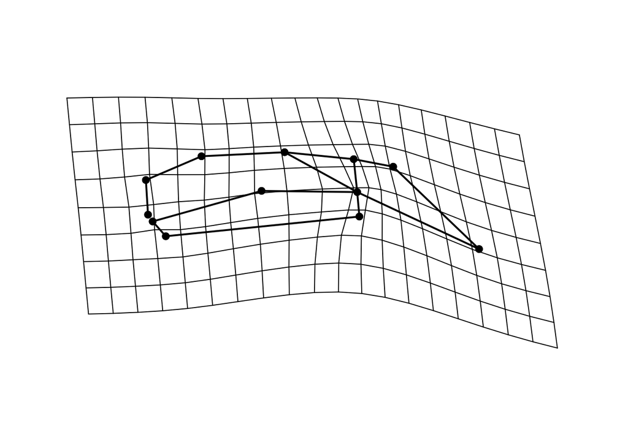

```r
X <- X[,-1]
symJord <- c(0,1,0) # design for P. Jordani in sympatry
alloJord <- c(0,0,0) # design for P. Jordani in allopatry
preds <- shape.predictor(arrayspecs(pleth.anova$fitted, 12,2), x = X, Intercept = TRUE,
                         symJord=symJord, alloJord=alloJord)
plotRefToTarget(M, preds$symJord, links = plethodon$links, mag=2)
```

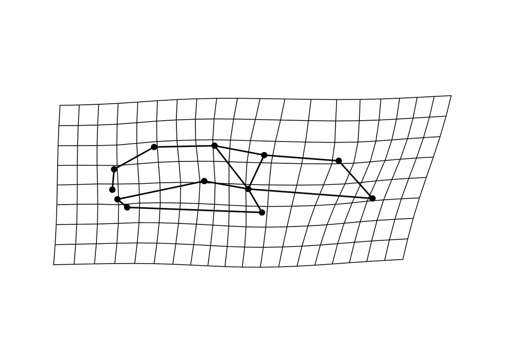

```r
plotRefToTarget(M, preds$alloJord, links = plethodon$links, mag=2)
```

`Picknplot.shape` examples are available in the lab script.

### Specifying Error: Mixed Effects Models

Sometimes, the terms in our model represent random effects; such as is found in a nested model. Here one must designate *WHICH* factor’s SS represents the error term against which another factor is compared. This is done using the `error` argument in `anova`:

```r
data("larvalMorph")
Y.gpa <- gpagen(larvalMorph$tailcoords, curves = larvalMorph$tail.sliders,
ProcD = TRUE, print.progress = FALSE)
gdf <- geomorph.data.frame(Y.gpa, treatment = larvalMorph$treatment,
family = larvalMorph$family)

fit <- procD.lm(coords ~ treatment/family, data = gdf,
print.progress = FALSE, iter = 199)
anova(fit) # treatment effect not adjusted
```

```
##
## Analysis of Variance, using Residual Randomization
## Permutation procedure: Randomization of null model residuals
## Number of permutations: 200
## Estimation method: Ordinary Least Squares
## Sums of Squares and Cross-products: Type I
## Effect sizes (Z) based on F distributions
##
##                   Df      SS        MS     Rsq      F      Z Pr(>F)
## treatment          5 0.08668 0.0173370 0.23126 6.9792 4.1279  0.005 **
## treatment:family  18 0.06458 0.0035881 0.17230 1.4444 2.4016  0.015 *
## Residuals         90 0.22357 0.0024841 0.59644
## Total            113 0.37484
## ---
## Signif. codes:  0 '***' 0.001 '**' 0.01 '*' 0.05 '.' 0.1 ' ' 1
##
## Call: procD.lm(f1 = coords ~ treatment/family, iter = 199, data = gdf,
##     print.progress = FALSE)
```

```r
anova(fit, error = c("treatment:family", "Residuals")) # treatment effect updated (adjusted)
```

```
##
## Analysis of Variance, using Residual Randomization
## Permutation procedure: Randomization of null model residuals
## Number of permutations: 200
## Estimation method: Ordinary Least Squares
## Sums of Squares and Cross-products: Type I
## Effect sizes (Z) based on F distributions
##
##                   Df      SS        MS     Rsq      F      Z Pr(>F)
## treatment          5 0.08668 0.0173370 0.23126 4.8319 3.5682  0.005 **
## treatment:family  18 0.06458 0.0035881 0.17230 1.4444 2.4016  0.015 *
## Residuals         90 0.22357 0.0024841 0.59644
## Total            113 0.37484
## ---
## Signif. codes:  0 '***' 0.001 '**' 0.01 '*' 0.05 '.' 0.1 ' ' 1
##
## Call: procD.lm(f1 = coords ~ treatment/family, iter = 199, data = gdf,
##     print.progress = FALSE)
```